# Tools for Software Development

Di Cook, Heike Hofmann  
2/3/2014

### Outline

- Problems of team work
- git in RStudio

### Working as a team

How do you work with other people on a team project?

How often do you find yourself sending documents back and forth by email and then scanning them (at the last minute) for the changes that everybody made?

… and trying to incorporate the changes you made in the last two hours …

### Another problem

You are still working in that team, and you just got feedback from your instructor …

How do you keep track of which version is the current/best version?

Do you have files named XXX-Jan15.doc, XXX-Jan16.doc, … ?

My major professor also liked XXX-Jan15-au-rev2.doc

### Version control systems

Enable collaborative work

Provides *concurrency* (merging changes by multiple people), *reversibility* (reverting to a previous version), *annotation* (documenting reasons for changes that are made)

Used for software development, document writing, web site development by teams of people

### Setup and working process (git)

Documents are stored on a server (usually not on your own machine, but you can run git locally). This is the main reference for everybody.

Contributors check out copies to their local machines and make changes

Contributors check changes back into the main reference files on the server. This is where conflicts with other contributors' changes can occur - they have to get resolved at that point, so that the reference file is always a reflection of the current state of the project.

Resources: [git](http://git-scm.com/book/en/Getting-Started)

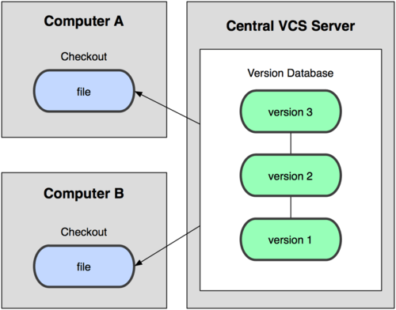

### Other VCS vs git structure

Tradtional system: Keeps changes relative to a base version

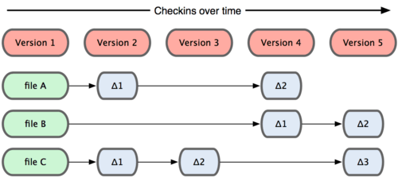

Git: thinks of its data more like a set of snapshots of a mini filesystem. Every time you commit, or save the state of your project in Git, it basically takes a picture of what all your files look like at that moment and stores a reference to that snapshot. To be efficient, if files have not changed, Git doesn’t store the file again—just a link to the previous identical file it has already stored.

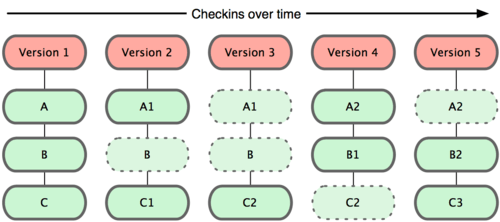

### git Workflow

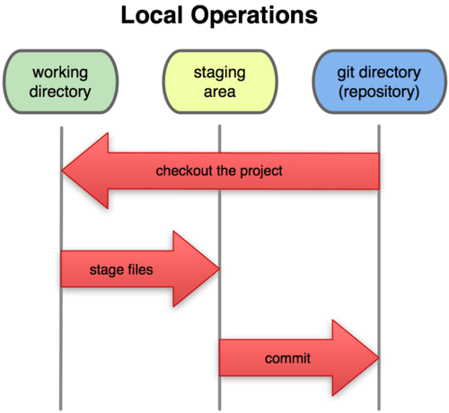

The basic Git workflow goes something like this:

- You modify files in your working directory.
- You stage the files, adding snapshots of them to your staging area.
- You do a commit, which takes the files as they are in the staging area and stores that snapshot permanently to your Git directory.

### Project examples

- cranvas Interactive graphics project, with many contributors
- dicook Di's personal repository
- heike Heike's personal repository
- [lindsey](https://github.com/lmjackson) Lindsey's personal repository

### Last year's story project

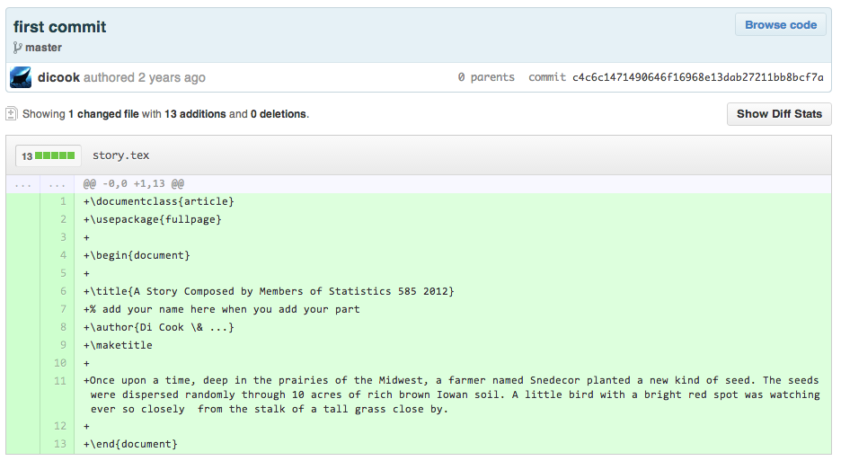

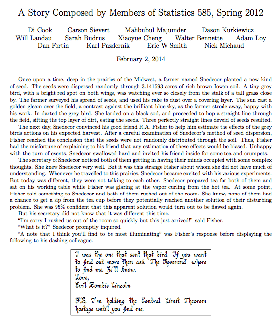

### Getting started with github

GitHub [https://github.com] is an implementation of git.

For “Powerful collaboration, code review, and code management for open source and private projects”

Public repositories are free, you only need to pay if you want to have private repositories.

Sign up for github [https://github.com/signup/free], and send your login to Di and/or Heike, we will add you to the stat 585 repository.

### Interfaces to github

RStudio has a github interface … this might be the easiest to use for us right now.

Create a new project using the option “Version Control”.

You can find the link to the existing repository on the repo's website under “SSH clone website” [git@github.com:heike/stat585.git] A repository is nothing but a folder containing files or other folders.

Pick a directory on your local machine where you have write permission.

You get a copy of the current version of the repository on your machine. This process is called cloning

`git clone git@github.com:heike/stat585.git`

### Making changes - two main ways

(1) You can add new files to the repository (by creating them or copying them into the local folder) or remove files from the repository. Careful with that!!!

`git add filename`

`git remove filename`

(2) You can change existing files. This is what we usually do. In Rstudio, changes in existing files are marked by turning the icon on the side blue.

`git status`

### Committing changes

All changes to the local repository have to be *committed* before we can transfer them to the main repository.

`git commit filename`

Committing needs a (one-line) summary of what change was done to the file (this is for annotation).

### Transferring changes

transferring local changes to the main repository is called *pushing*

`git push`

updating the local repository and integrating changes from the main repository is called *pulling*

`git pull`

### Conflicts

```
# Load libraries
library(ggplot2)

# Read data
eye <- read.csv(file.choose())
eye <- unique(eye)

# Plot
>>>> main/header
qplot(Left.Gaze.Point.X, -Left.Gaze.Point.Y, data=eye, colour=I("orange"), alpha=I(0.01), size=I(10)) + geom_point(aes(x=Right.Gaze.Point.X, y=-Right.Gaze.Point.Y), colour=I("blue"), alpha=I(0.01), size=I(10))
 ====
qplot(Left.Gaze.Point.X, -Left.Gaze.Point.Y, data=eye, colour=I("purple"), alpha=I(0.1), size=I(5)) + geom_point(aes(x=Right.Gaze.Point.X, y=-Right.Gaze.Point.Y), colour=I("green"), alpha=I(0.1), size=I(5))
<<<<
```

### Conflicts

Resolve the conflict by deleting/adjusting the paragraph. Get rid of the >>>>, ====, and <<<<

Commit the change and push/pull

### Doing all of these within RStudio

1 Create new project, selecting version control

[figure not shown]

2 Choose version control type git

[figure not shown]

3 Set it to pull from Heike's starting repository

[figure not shown]

4 Create a new file, or edit the normal.R file, and select it for committing

[figure not shown]

### Doing all of these within RStudio

5 Prepare to commit change, along with a text explanation

[figure not shown]

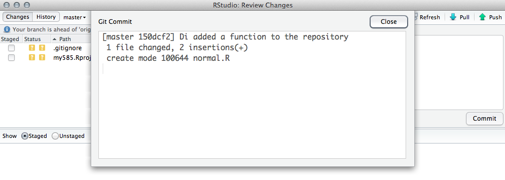

7 Push the change onto the repository

[figure not shown]

8 All done

[figure not shown]

### Git - practical advice

- Pull before you start working on a project - somebody might have changed things without letting you know
- Push often, small changes usually do not lead to conflicts; but if they do it is generally easier to resolve them.
- Once you've pushed, pull again (sometimes changes to the global repository force you to pull first).